# Mindset-Mindfulness Experiment Data Analysis

XXX

21/7/2021

```r
knitr::opts_chunk$set(echo = TRUE)

library(tidyverse)
library(broom)
library(sjPlot)
library(pscl)
library(performance)
library(skimr)
library(report)
library(ggbeeswarm)
library(scales)
library(gt)
library(patchwork)

theme_set(theme_light())
```

# Read data

Data processing is available in “script/data_processing.R”. We only use the processed data.

```r
processed_final <- read_csv(here::here("data/processed_final.csv"))
```

# Data exploration and descriptives

## Sample

```r
processed_final %>%
  report_participants(sex = "gender")
```

[1] “383 participants (Mean age = 22.3, SD = 4.2, range: [18, 53]; 79.9% females; Education: Egyetem, 12.53%; Érettségi, 4.70%; Folyamatban lévo egyetemi tanulmányok, 82.77%)”

```r
processed_final %>%
  select(gender, education, field, meditation, coffee, alcohol) %>%
  mutate(across(where(is.character), as.factor)) %>%
  summary()
```

```
##     gender                                    education
##  Female:306   Egyetem                              : 48
##  Male  : 77   Érettségi                            : 18
##               Folyamatban lévo egyetemi tanulmányok:317
##
##
##
##
##                          field                  meditation
##  pszichológia               : 21   Egy héten többször: 20
##  Pszichológia               : 16   Havonta           : 62
##  gyógypedagógia             : 11   Heti egyszer      : 18
##  Gyógypedagógia             : 10   Naponta           :  2
##  Biológia                   :  8   Soha              :281
##  Programtervezo informatikus:  8
##  (Other)                    :309
##                       coffee                                       alcohol
##  Egy csészével.          : 97   Egy egységnyit fogyasztottam.          : 22
##  Három csészével.        : 25   Egyáltalán nem fogyasztottam.          :331
##  Két csészével.          : 81   Három egységnyit fogyasztottam.        :  5
##  Négy csészével.         :  5   Két egységnyit fogyasztottam.          :  8
##  Öt csészével.           :  3   Négy egységnyit fogyasztottam.         :  7
##  Semennyit.              :170   Öt egységnyit fogyasztottam.           :  4
##  Több, mint öt csészével.:  2   Több, mint öt egységnyit fogyasztottam.:  6
```

## Descriptive statistics

### All participants

First, we present the main descriptives of the whole sample for the outcomes and potential moderators.

```r
processed_final %>%
  select(
    extra_tasks,
    ms_mean,
    cams_mean,
    risc_mean,
    grit_mean,
    sc_mean,
    se_mean,
    iq_final:iq_warmup,
    out_1:out_3) %>%
  skim()
```

Data summary

| Name | Piped data |
| --- | --- |
| Number of rows | 383 |
| Number of columns | 14 |
| _______________________ |  |
| Column type frequency: |  |
| numeric | 14 |
| ________________________ |  |
| Group variables | None |

**Variable type: numeric**

| skim_variable | n_missing | complete_rate | mean | sd | p0 | p25 | p50 | p75 | p100 | hist |
| --- | --- | --- | --- | --- | --- | --- | --- | --- | --- | --- |
| extra_tasks | 0 | 1.00 | 3.57 | 4.51 | 0.00 | 0.00 | 2.00 | 5.00 | 17.00 | ▇▂▁▁▁ |
| ms_mean | 0 | 1.00 | 4.01 | 1.03 | 1.00 | 3.25 | 4.00 | 4.75 | 6.00 | ▁▅▇▇▃ |
| cams_mean | 0 | 1.00 | 2.81 | 0.41 | 1.58 | 2.58 | 2.83 | 3.08 | 3.83 | ▁▂▇▅▂ |
| risc_mean | 0 | 1.00 | 2.80 | 0.46 | 1.64 | 2.45 | 2.82 | 3.18 | 3.91 | ▂▆▇▅▂ |
| grit_mean | 2 | 0.99 | 2.66 | 0.70 | 1.12 | 2.12 | 2.62 | 3.12 | 4.88 | ▃▇▇▂▁ |
| sc_mean | 0 | 1.00 | 2.99 | 0.63 | 1.25 | 2.50 | 3.00 | 3.50 | 4.58 | ▁▅▇▆▁ |
| se_mean | 2 | 0.99 | 2.02 | 0.55 | 0.56 | 1.67 | 2.00 | 2.44 | 3.00 | ▁▂▇▅▅ |
| iq_final | 0 | 1.00 | 0.51 | 0.16 | 0.08 | 0.42 | 0.50 | 0.59 | 0.91 | ▁▃▇▆▂ |
| iq_practice | 131 | 0.66 | 0.87 | 0.22 | 0.00 | 0.80 | 1.00 | 1.00 | 1.00 | ▁▁▁▂▇ |
| iq_real | 0 | 1.00 | 0.73 | 0.18 | 0.08 | 0.64 | 0.75 | 0.83 | 1.00 | ▁▁▃▇▇ |
| iq_warmup | 0 | 1.00 | 0.56 | 0.18 | 0.08 | 0.42 | 0.58 | 0.70 | 1.00 | ▂▅▇▇▂ |
| out_1 | 0 | 1.00 | 0.00 | 0.96 | -1.93 | -0.69 | 0.16 | 0.74 | 1.63 | ▅▅▇▇▆ |
| out_2 | 0 | 1.00 | 0.00 | 0.96 | -1.41 | -0.65 | -0.01 | 0.79 | 2.46 | ▆▇▆▃▁ |
| out_3 | 0 | 1.00 | 0.00 | 0.96 | -2.80 | -0.27 | -0.17 | 0.65 | 1.55 | ▁▂▆▇▃ |

### Grouped by manipulated variables

Second, we present the outcomes and potential moderators grouped by the manipulated variables (mindset and mindfulness induction).

```r
processed_final %>%
  select(
    mindset,
    intervention,
    extra_tasks,
    ms_mean,
    cams_mean,
    risc_mean,
    grit_mean,
    sc_mean,
    se_mean,
    iq_final:iq_warmup,
    out_1:out_3) %>%
  group_by(mindset, intervention) %>%
  skim()
```

Data summary

| Name | Piped data |
| --- | --- |
| Number of rows | 383 |
| Number of columns | 16 |
| _______________________ |  |
| Column type frequency: |  |
| numeric | 14 |
| ________________________ |  |
| Group variables | mindset, intervention |

**Variable type: numeric**

| skim_variable | mindset | intervention | n_missing | complete_rate | mean | sd | p0 | p25 | p50 | p75 | p100 | hist |
| --- | --- | --- | --- | --- | --- | --- | --- | --- | --- | --- | --- | --- |
| extra_tasks | Fixed | Control | 0 | 1.00 | 3.33 | 4.03 | 0.00 | 0.00 | 2.00 | 5.00 | 17.00 | ▇▃▁▁▁ |
| extra_tasks | Fixed | Mindfulness | 0 | 1.00 | 3.27 | 4.59 | 0.00 | 0.00 | 1.00 | 5.00 | 17.00 | ▇▂▁▁▁ |
| extra_tasks | Growth | Control | 0 | 1.00 | 4.09 | 4.81 | 0.00 | 0.00 | 2.00 | 6.00 | 17.00 | ▇▃▁▁▁ |
| extra_tasks | Growth | Mindfulness | 0 | 1.00 | 3.57 | 4.52 | 0.00 | 0.00 | 2.00 | 5.00 | 17.00 | ▇▂▁▁▁ |
| ms_mean | Fixed | Control | 0 | 1.00 | 4.02 | 1.03 | 1.75 | 3.25 | 4.00 | 4.75 | 6.00 | ▂▃▇▆▃ |
| ms_mean | Fixed | Mindfulness | 0 | 1.00 | 3.90 | 1.10 | 1.75 | 3.00 | 4.00 | 4.75 | 6.00 | ▃▃▇▃▃ |
| ms_mean | Growth | Control | 0 | 1.00 | 4.14 | 0.93 | 2.00 | 3.50 | 4.25 | 4.75 | 6.00 | ▃▅▇▇▃ |
| ms_mean | Growth | Mindfulness | 0 | 1.00 | 3.97 | 1.07 | 1.00 | 3.25 | 4.00 | 4.75 | 6.00 | ▂▃▆▇▃ |
| cams_mean | Fixed | Control | 0 | 1.00 | 2.80 | 0.39 | 1.67 | 2.58 | 2.88 | 3.08 | 3.50 | ▁▂▆▇▅ |
| cams_mean | Fixed | Mindfulness | 0 | 1.00 | 2.78 | 0.46 | 1.58 | 2.58 | 2.83 | 3.00 | 3.83 | ▁▂▇▃▂ |
| cams_mean | Growth | Control | 0 | 1.00 | 2.84 | 0.40 | 1.58 | 2.58 | 2.83 | 3.08 | 3.67 | ▁▃▆▇▃ |
| cams_mean | Growth | Mindfulness | 0 | 1.00 | 2.83 | 0.38 | 2.00 | 2.58 | 2.83 | 3.15 | 3.75 | ▃▇▇▇▂ |
| risc_mean | Fixed | Control | 0 | 1.00 | 2.78 | 0.50 | 1.64 | 2.45 | 2.82 | 3.18 | 3.91 | ▃▇▇▆▃ |
| risc_mean | Fixed | Mindfulness | 0 | 1.00 | 2.78 | 0.42 | 1.91 | 2.45 | 2.73 | 3.09 | 3.73 | ▃▇▇▅▃ |
| risc_mean | Growth | Control | 0 | 1.00 | 2.87 | 0.48 | 1.82 | 2.55 | 2.82 | 3.18 | 3.91 | ▃▇▇▆▃ |
| risc_mean | Growth | Mindfulness | 0 | 1.00 | 2.77 | 0.43 | 1.82 | 2.55 | 2.73 | 3.18 | 3.64 | ▂▃▇▅▃ |
| grit_mean | Fixed | Control | 2 | 0.98 | 2.73 | 0.68 | 1.50 | 2.34 | 2.62 | 3.03 | 4.88 | ▃▇▃▂▁ |
| grit_mean | Fixed | Mindfulness | 0 | 1.00 | 2.65 | 0.75 | 1.38 | 2.03 | 2.62 | 3.12 | 4.62 | ▇▇▇▅▂ |
| grit_mean | Growth | Control | 0 | 1.00 | 2.63 | 0.70 | 1.25 | 2.12 | 2.62 | 3.12 | 4.25 | ▃▇▇▆▂ |
| grit_mean | Growth | Mindfulness | 0 | 1.00 | 2.62 | 0.67 | 1.12 | 2.12 | 2.69 | 3.12 | 4.38 | ▃▇▇▆▁ |
| sc_mean | Fixed | Control | 0 | 1.00 | 3.00 | 0.64 | 1.33 | 2.58 | 3.08 | 3.42 | 4.25 | ▁▅▆▇▃ |
| sc_mean | Fixed | Mindfulness | 0 | 1.00 | 2.98 | 0.66 | 1.42 | 2.50 | 2.92 | 3.48 | 4.58 | ▂▃▇▅▁ |
| sc_mean | Growth | Control | 0 | 1.00 | 3.00 | 0.58 | 1.25 | 2.58 | 3.00 | 3.42 | 4.33 | ▁▃▇▆▂ |
| sc_mean | Growth | Mindfulness | 0 | 1.00 | 3.00 | 0.65 | 1.75 | 2.42 | 3.08 | 3.50 | 4.25 | ▆▆▇▇▃ |
| se_mean | Fixed | Control | 2 | 0.98 | 1.92 | 0.52 | 0.67 | 1.56 | 1.89 | 2.33 | 3.00 | ▂▅▇▆▃ |
| se_mean | Fixed | Mindfulness | 0 | 1.00 | 2.04 | 0.57 | 0.56 | 1.69 | 2.00 | 2.44 | 3.00 | ▂▂▇▆▆ |
| se_mean | Growth | Control | 0 | 1.00 | 2.08 | 0.55 | 0.67 | 1.67 | 2.00 | 2.56 | 3.00 | ▂▃▇▆▆ |
| se_mean | Growth | Mindfulness | 0 | 1.00 | 2.04 | 0.54 | 0.78 | 1.67 | 2.00 | 2.53 | 3.00 | ▃▃▇▆▃ |
| iq_final | Fixed | Control | 0 | 1.00 | 0.51 | 0.17 | 0.08 | 0.42 | 0.50 | 0.64 | 0.83 | ▁▃▇▇▂ |
| iq_final | Fixed | Mindfulness | 0 | 1.00 | 0.50 | 0.16 | 0.08 | 0.42 | 0.50 | 0.63 | 0.88 | ▁▃▇▅▂ |
| iq_final | Growth | Control | 0 | 1.00 | 0.50 | 0.16 | 0.08 | 0.42 | 0.50 | 0.58 | 0.83 | ▁▅▇▇▂ |
| iq_final | Growth | Mindfulness | 0 | 1.00 | 0.51 | 0.14 | 0.08 | 0.42 | 0.50 | 0.58 | 0.91 | ▁▃▇▅▂ |
| iq_practice | Fixed | Control | 31 | 0.66 | 0.83 | 0.27 | 0.00 | 0.80 | 1.00 | 1.00 | 1.00 | ▁▁▁▁▇ |
| iq_practice | Fixed | Mindfulness | 36 | 0.65 | 0.88 | 0.22 | 0.00 | 0.83 | 1.00 | 1.00 | 1.00 | ▁▁▁▁▇ |
| iq_practice | Growth | Control | 33 | 0.67 | 0.87 | 0.18 | 0.33 | 0.79 | 1.00 | 1.00 | 1.00 | ▁▂▁▂▇ |
| iq_practice | Growth | Mindfulness | 31 | 0.66 | 0.88 | 0.21 | 0.00 | 0.80 | 1.00 | 1.00 | 1.00 | ▁▁▁▂▇ |
| iq_real | Fixed | Control | 0 | 1.00 | 0.74 | 0.18 | 0.17 | 0.67 | 0.75 | 0.88 | 1.00 | ▁▂▅▇▅ |
| iq_real | Fixed | Mindfulness | 0 | 1.00 | 0.74 | 0.17 | 0.08 | 0.67 | 0.75 | 0.83 | 1.00 | ▁▁▃▇▇ |
| iq_real | Growth | Control | 0 | 1.00 | 0.72 | 0.18 | 0.25 | 0.60 | 0.75 | 0.83 | 1.00 | ▁▂▅▇▅ |
| iq_real | Growth | Mindfulness | 0 | 1.00 | 0.72 | 0.17 | 0.33 | 0.64 | 0.75 | 0.83 | 1.00 | ▃▃▇▇▆ |
| iq_warmup | Fixed | Control | 0 | 1.00 | 0.58 | 0.19 | 0.08 | 0.43 | 0.64 | 0.73 | 0.89 | ▁▃▅▇▅ |
| iq_warmup | Fixed | Mindfulness | 0 | 1.00 | 0.57 | 0.18 | 0.08 | 0.45 | 0.58 | 0.72 | 1.00 | ▁▃▇▇▂ |
| iq_warmup | Growth | Control | 0 | 1.00 | 0.54 | 0.18 | 0.08 | 0.42 | 0.55 | 0.67 | 1.00 | ▂▅▇▇▂ |
| iq_warmup | Growth | Mindfulness | 0 | 1.00 | 0.54 | 0.18 | 0.08 | 0.42 | 0.55 | 0.67 | 0.90 | ▁▅▆▇▃ |
| out_1 | Fixed | Control | 0 | 1.00 | 0.12 | 0.86 | -1.91 | -0.46 | 0.22 | 0.79 | 1.63 | ▂▅▆▇▃ |
| out_1 | Fixed | Mindfulness | 0 | 1.00 | -0.08 | 1.00 | -1.91 | -0.75 | 0.11 | 0.66 | 1.62 | ▇▅▇▇▇ |
| out_1 | Growth | Control | 0 | 1.00 | -0.10 | 1.00 | -1.92 | -0.93 | 0.09 | 0.69 | 1.62 | ▆▅▇▇▆ |
| out_1 | Growth | Mindfulness | 0 | 1.00 | 0.08 | 0.95 | -1.93 | -0.42 | 0.20 | 0.75 | 1.62 | ▃▂▇▇▆ |
| out_2 | Fixed | Control | 0 | 1.00 | -0.02 | 0.85 | -1.36 | -0.57 | -0.19 | 0.70 | 2.34 | ▅▇▅▃▁ |
| out_2 | Fixed | Mindfulness | 0 | 1.00 | -0.02 | 0.97 | -1.36 | -0.67 | 0.01 | 0.78 | 2.46 | ▇▇▇▂▂ |
| out_2 | Growth | Control | 0 | 1.00 | 0.07 | 0.99 | -1.35 | -0.65 | 0.06 | 0.87 | 2.38 | ▇▇▆▅▂ |
| out_2 | Growth | Mindfulness | 0 | 1.00 | -0.03 | 1.03 | -1.41 | -1.03 | -0.21 | 0.66 | 2.41 | ▇▇▆▃▂ |
| out_3 | Fixed | Control | 0 | 1.00 | 0.00 | 0.94 | -2.80 | -0.25 | -0.18 | 0.64 | 1.55 | ▁▂▆▇▅ |
| out_3 | Fixed | Mindfulness | 0 | 1.00 | -0.06 | 0.99 | -2.72 | -1.00 | -0.18 | 0.65 | 1.52 | ▂▅▇▇▅ |
| out_3 | Growth | Control | 0 | 1.00 | 0.03 | 0.95 | -2.73 | -0.24 | -0.17 | 0.64 | 1.53 | ▂▂▇▇▃ |
| out_3 | Growth | Mindfulness | 0 | 1.00 | 0.05 | 0.97 | -2.75 | -0.94 | -0.15 | 0.65 | 1.53 | ▁▂▆▇▅ |

## Compare baseline characteristics

```r
# Group Ns
processed_final %>%
  count(mindset, intervention) %>%
  pivot_wider(names_from = c(mindset, intervention),
              names_sep = " - ",
              values_from = n) %>%
  gt() %>%
    tab_options(row.striping.include_table_body = TRUE,
              row.striping.background_color = "#EEEEEE",
              row.striping.include_stub = TRUE,
              column_labels.background.color = "#CCCCCC",
              column_labels.font.weight = "bold") %>%
   tab_header(title = "Number of participants by group")
```

Number of participants by group

| Fixed - Control | Fixed - Mindfulness | Growth - Control | Growth - Mindfulness |
| --- | --- | --- | --- |
| 90 | 102 | 101 | 90 |

```r
# Group gender Ns
processed_final %>%
  count(mindset, intervention, Gender = gender) %>%
    pivot_wider(names_from = c(mindset, intervention),
              names_sep = " - ",
              values_from = n) %>%
  gt() %>%
    tab_options(row.striping.include_table_body = TRUE,
              row.striping.background_color = "#EEEEEE",
              row.striping.include_stub = TRUE,
              column_labels.background.color = "#CCCCCC",
              column_labels.font.weight = "bold") %>%
   tab_header(title = "Number of participants of each gender by group")
```

Number of participants of each gender by group

| Gender | Fixed - Control | Fixed - Mindfulness | Growth - Control | Growth - Mindfulness |
| --- | --- | --- | --- | --- |
| Female | 74 | 79 | 82 | 71 |
| Male | 16 | 23 | 19 | 19 |

```r
scale_names <- c("age" = "Age",
                 "gender" = "Gender: Male",
                 "ms" = "Prior growth mindset",
                 "cams" = "Trait mindfulness",
                 "risc" = "Ego-resilience",
                 "grit" = "Grit",
                 "sc" = "Self-compassion",
                 "se" = "Global self-esteem")

processed_final %>%
  select(
    mindset, intervention,
    gender, age,
    ms_mean, cams_mean, risc_mean, grit_mean, sc_mean, se_mean) %>%
  mutate(gender = recode(gender, `Female` = 0L, `Male` = 1L)) %>%
  group_by(mindset, intervention) %>%
  summarise(across(gender:se_mean,
                   list("Mean" = mean, "SD" = sd), na.rm = TRUE),
            .groups = "drop") %>%
  pivot_longer(-c("mindset", "intervention")) %>%
  mutate(name = str_remove(name, "_mean")) %>%
  separate(name, into = c("Measure", "stat")) %>%
  pivot_wider(names_from = "stat", values_from = "value") %>%
  mutate(Measure = recode(Measure, !!!scale_names)) %>%
  unite("group", c("mindset", "intervention"), sep = "-") %>%
  mutate(across(c(Mean, SD), ~round(.x, 2) %>%
                              format(nsmall = 2))) %>%
  unite("mn", c("Mean", "SD"), sep = " (") %>%
  mutate(mn = paste0(mn, ")")) %>%
  pivot_wider(names_from = "group", values_from = "mn") %>%
  mutate(across(-Measure, ~if_else(Measure == "Gender: Male",
                                    str_remove(.x, "\\(.*\\)") %>%
                                       parse_number() %>%
                                       percent(accuracy = .1),
                                    .x) %>%
                           str_squish())) %>%
  gt() %>%
  tab_spanner(label = "Group",
              columns = `Fixed-Control`:`Growth-Mindfulness`) %>%
  tab_options(row.striping.include_table_body = TRUE,
              row.striping.background_color = "#EEEEEE",
              row.striping.include_stub = TRUE,
              column_labels.background.color = "#CCCCCC",
              column_labels.font.weight = "bold"
              )
```

| Measure | Group Fixed-Control | Group Fixed-Mindfulness | Group Growth-Control | Group Growth-Mindfulness |
| --- | --- | --- | --- | --- |
| Gender: Male | 18.0% | 23.0% | 19.0% | 21.0% |
| Age | 21.94 (2.38) | 22.28 (4.33) | 22.86 (4.89) | 22.14 (4.63) |
| Prior growth mindset | 4.02 (1.03) | 3.90 (1.10) | 4.14 (0.93) | 3.97 (1.07) |
| Trait mindfulness | 2.80 (0.39) | 2.78 (0.46) | 2.84 (0.40) | 2.83 (0.38) |
| Ego-resilience | 2.78 (0.50) | 2.78 (0.42) | 2.87 (0.48) | 2.77 (0.43) |
| Grit | 2.73 (0.68) | 2.65 (0.75) | 2.63 (0.70) | 2.62 (0.67) |
| Self-compassion | 3.00 (0.64) | 2.98 (0.66) | 3.00 (0.58) | 3.00 (0.65) |
| Global self-esteem | 1.92 (0.52) | 2.04 (0.57) | 2.08 (0.55) | 2.04 (0.54) |

```r
processed_final %>%
  select(
    mindset,
    intervention,
    gender, age,
    ms_mean,
    cams_mean,
    risc_mean,
    grit_mean,
    sc_mean,
    se_mean) %>%
  mutate(gender = recode(gender, `Female` = 0L, `Male` = 1L)) %>%
  pivot_longer(-c(mindset, intervention)) %>%
  mutate(name = str_remove(name, "_mean") %>%
                recode(!!!scale_names)) %>%
  group_by(name) %>%
  nest() %>%
  mutate(mod = map(data, ~lm(value ~  mindset * intervention, data = .x) %>%
                          tidy())) %>%
  unnest(mod) %>%
  select(-data) %>%
  gt() %>%
  fmt_number(estimate:statistic, decimals = 2) %>%
  fmt_number(p.value, decimals = 4) %>%
  tab_options(row.striping.include_table_body = TRUE,
              row.striping.background_color = "#EEEEEE",
              row.striping.include_stub = TRUE,
              column_labels.background.color = "#CCCCCC",
              column_labels.font.weight = "bold",
              row_group.background.color = "#CCCCCC",
              row_group.font.weight = "bold")
```

| term | estimate | std.error | statistic | p.value |
| --- | --- | --- | --- | --- |
| Gender: Male |  |  |  |  |
| (Intercept) | 0.18 | 0.04 | 4.19 | 0.0000 |
| mindsetGrowth | 0.01 | 0.06 | 0.18 | 0.8594 |
| interventionMindfulness | 0.05 | 0.06 | 0.82 | 0.4129 |
| mindsetGrowth:interventionMindfulness | −0.02 | 0.08 | −0.30 | 0.7644 |
| Age |  |  |  |  |
| (Intercept) | 21.94 | 0.44 | 49.50 | 0.0000 |
| mindsetGrowth | 0.92 | 0.61 | 1.50 | 0.1334 |
| interventionMindfulness | 0.34 | 0.61 | 0.56 | 0.5766 |
| mindsetGrowth:interventionMindfulness | −1.06 | 0.86 | −1.23 | 0.2205 |
| Prior growth mindset |  |  |  |  |
| (Intercept) | 4.02 | 0.11 | 36.95 | 0.0000 |
| mindsetGrowth | 0.12 | 0.15 | 0.80 | 0.4262 |
| interventionMindfulness | −0.12 | 0.15 | −0.80 | 0.4221 |
| mindsetGrowth:interventionMindfulness | −0.05 | 0.21 | −0.25 | 0.8057 |
| Trait mindfulness |  |  |  |  |
| (Intercept) | 2.80 | 0.04 | 64.71 | 0.0000 |
| mindsetGrowth | 0.04 | 0.06 | 0.66 | 0.5102 |
| interventionMindfulness | −0.02 | 0.06 | −0.35 | 0.7302 |
| mindsetGrowth:interventionMindfulness | 0.02 | 0.08 | 0.20 | 0.8448 |
| Ego-resilience |  |  |  |  |
| (Intercept) | 2.78 | 0.05 | 57.48 | 0.0000 |
| mindsetGrowth | 0.09 | 0.07 | 1.31 | 0.1924 |
| interventionMindfulness | 0.00 | 0.07 | 0.03 | 0.9793 |
| mindsetGrowth:interventionMindfulness | −0.10 | 0.09 | −1.02 | 0.3094 |
| Grit |  |  |  |  |
| (Intercept) | 2.73 | 0.07 | 36.46 | 0.0000 |
| mindsetGrowth | −0.10 | 0.10 | −1.01 | 0.3112 |
| interventionMindfulness | −0.08 | 0.10 | −0.79 | 0.4308 |
| mindsetGrowth:interventionMindfulness | 0.08 | 0.14 | 0.53 | 0.5958 |
| Self-compassion |  |  |  |  |
| (Intercept) | 3.00 | 0.07 | 45.00 | 0.0000 |
| mindsetGrowth | 0.00 | 0.09 | −0.02 | 0.9830 |
| interventionMindfulness | −0.03 | 0.09 | −0.30 | 0.7658 |
| mindsetGrowth:interventionMindfulness | 0.03 | 0.13 | 0.23 | 0.8217 |
| Global self-esteem |  |  |  |  |
| (Intercept) | 1.92 | 0.06 | 33.04 | 0.0000 |
| mindsetGrowth | 0.16 | 0.08 | 1.96 | 0.0505 |
| interventionMindfulness | 0.12 | 0.08 | 1.46 | 0.1442 |
| mindsetGrowth:interventionMindfulness | −0.15 | 0.11 | −1.35 | 0.1789 |

The main outcome variable is the number of extra tasks that were performed in the optional practice block.

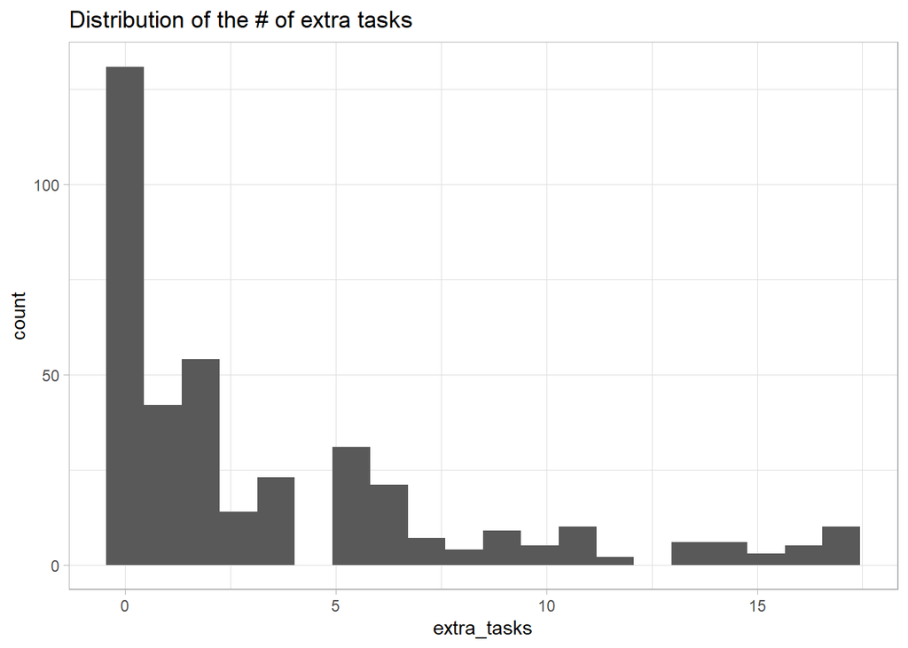

```r
processed_final %>%
  ggplot() +
  aes(x = extra_tasks) +
  geom_histogram(bins = 20) +
  labs(title = "Distribution of the # of extra tasks")
```

The secondary outcomes are the IQ test points obtained at three different points.

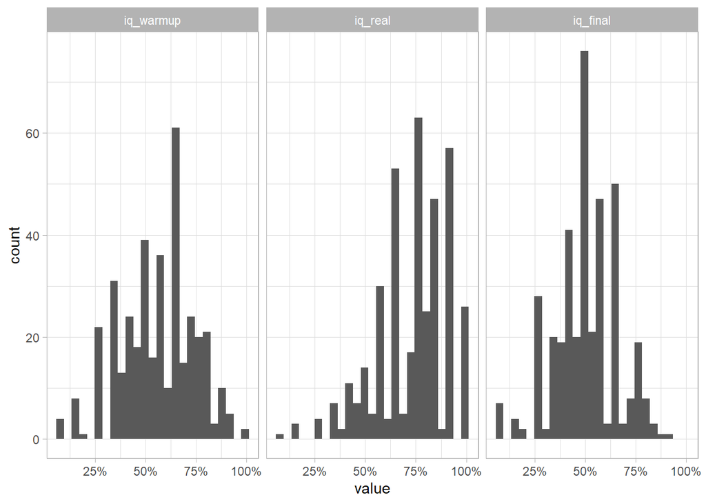

```r
processed_final %>%
  select(iq_warmup, iq_real, iq_final) %>%
  pivot_longer(everything()) %>%
  mutate(name = fct_inorder(name)) %>%
  ggplot() +
  aes(x = value) +
  geom_histogram(bins = 25) +
  scale_x_continuous(labels = percent_format()) +
  facet_wrap(~name)
```

# Induction check

The induction for mindset was successful, as those in the fixed mindset group had a stronger belief that intelligence cannot be changed over time. On the other hand, the mindfulness induction did not make the participants more mindful.

## Mindset manipulation check

```r
mindset_stat <- lm(mc_3 ~ mindset + ms_mean, data = processed_final)

tab_model(mindset_stat, show.df = TRUE)
```

|  | mc 3 |  |  |  |
| --- | --- | --- | --- | --- |
| Predictors | Estimates | CI | p | df |
| (Intercept) | 6.64 | 6.27 – 7.01 | **<0.001** | 380.00 |
| mindset [Growth] | -0.77 | -0.95 – -0.59 | **<0.001** | 380.00 |
| ms mean | -0.77 | -0.85 – -0.68 | **<0.001** | 380.00 |
| Observations | 383 |  |  |  |
| R<sup>2</sup> / R<sup>2</sup> adjusted | 0.501 / 0.498 |  |  |  |

```r
effectsize::cohens_d(mc_3 ~ mindset, data = processed_final)
```

```
## Cohen's d |       95% CI
## ------------------------
## 0.71      | [0.50, 0.91]
##
## - Estimated using pooled SD.
```

```r
mindset_check <-
  processed_final %>%
  ggplot() +
  aes(y = mindset, x = mc_3, fill = mindset) +
  geom_boxplot(show.legend = FALSE, width = .5, alpha = .7, outlier.alpha = 0) +
  geom_jitter(width = .2, alpha = .5, height = .2, show.legend = FALSE) +
  labs(subtitle = "Answer: \"Your intelligence is an attribute that you cannot change over time (1-6)\"",
       y = NULL,
       x = NULL)
```

## Mindfulness induction manipulation check

```r
mindfulness_stat <- lm(mc_1 ~ intervention + cams_mean,
                       data = processed_final)

tab_model(mindfulness_stat, show.df = TRUE)
```

|  | mc 1 |  |  |  |
| --- | --- | --- | --- | --- |
| Predictors | Estimates | CI | p | df |
| (Intercept) | 1.72 | 0.78 – 2.66 | **<0.001** | 380.00 |
| intervention [Mindfulness] | -0.07 | -0.33 – 0.20 | 0.629 | 380.00 |
| cams mean | 0.60 | 0.27 – 0.93 | **<0.001** | 380.00 |
| Observations | 383 |  |  |  |
| R<sup>2</sup> / R<sup>2</sup> adjusted | 0.034 / 0.029 |  |  |  |

```r
effectsize::cohens_d(mc_1 ~ intervention, data = processed_final)
```

```
## Cohen's d |        95% CI
## -------------------------
## 0.06      | [-0.14, 0.26]
##
## - Estimated using pooled SD.
```

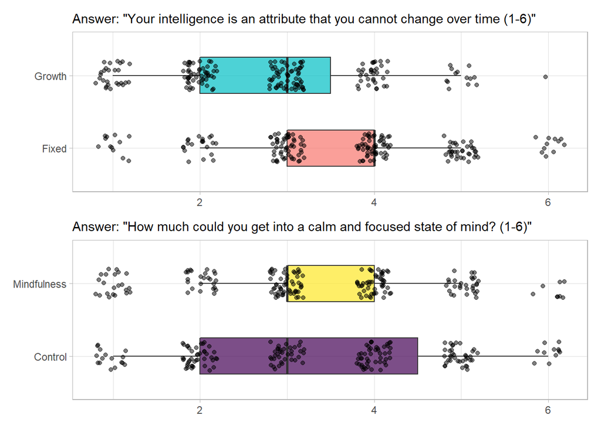

```r
mindfulness_check <-
  processed_final %>%
  ggplot() +
  aes(y = intervention, x = mc_1, fill = intervention) +
  geom_boxplot(show.legend = FALSE, width = .5, alpha = .7, outlier.alpha = 0) +
  geom_jitter(width = .2, alpha = .5, height = .2, show.legend = FALSE) +
  scale_fill_viridis_d() +
  labs(subtitle = "Answer: \"How much could you get into a calm and focused state of mind? (1-6)\"",
       x = NULL,
       y = NULL)

mindset_check + mindfulness_check + patchwork::plot_layout(nrow = 2)
```

```r
# ggsave("docs/figure_3.png", dpi = 300)
```

# Dispositional confounders of the manipulation

## Dispositional mindset

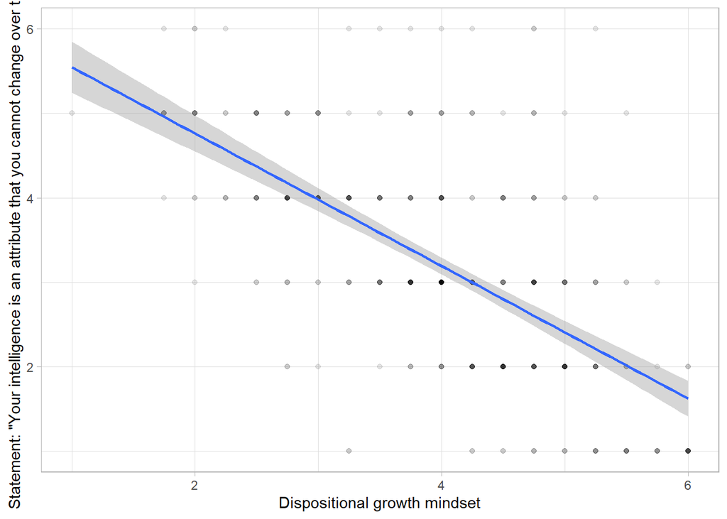

```r
processed_final %>%
  select(mc_1, mc_3, cams_mean, ms_mean) %>%
  ggplot() +
  aes(y = mc_3, x = ms_mean) +
  geom_point(alpha = .1) +
  geom_smooth(method = lm) +
  labs(x = "Dispositional growth mindset",
       y = "Statement: \"Your intelligence is an attribute that you cannot change over time\"")
```

## Dispositional mindfulness

Similarly, those with dispositional mindfulness were more likely to be able to get into a calm and focused state.

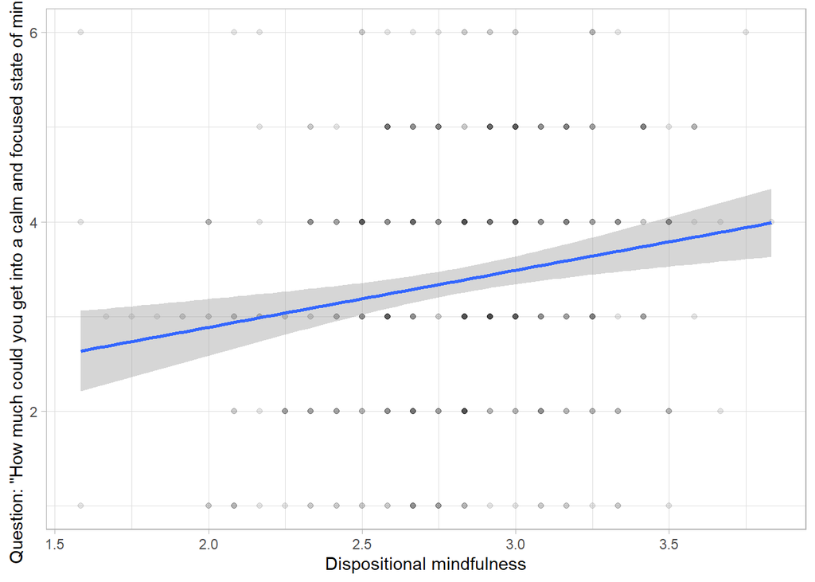

```r
processed_final %>%
  select(mc_1, mc_3, cams_mean, ms_mean) %>%
  ggplot() +
  aes(y = mc_1, x = cams_mean) +
  geom_point(alpha = .1) +
  geom_smooth(method = lm) +
  labs(x = "Dispositional mindfulness", y = "Question: \"How much could you get into a calm and focused state of mind?\"")
```

# Test main outcomes

## Number of solved optional exercises

We test the main hypothesis, that is the association of the mindset (fixed vs. growth) and mindfulness induction (mindfulness vs. control) with the number of solved optional exercises.

```r
mod_1 <- glm(extra_tasks ~ mindset * intervention,
           family = "poisson",
           data = processed_final)

mod_2 <- glm(extra_tasks ~ mindset + intervention,
             family = "poisson",
             data = processed_final)

tab_model(mod_1, mod_2,
          dv.labels = c("Interaction", "Only main effects"),
          show.aic = TRUE,
          show.stat = TRUE,
          p.style = "numeric",
          show.loglik = TRUE,
          show.dev = TRUE,
          show.zeroinf = TRUE)
```

|  | Interaction |  |  |  | Only main effects |  |  |  |
| --- | --- | --- | --- | --- | --- | --- | --- | --- |
| Predictors | Incidence Rate Ratios | CI | Statistic | p | Incidence Rate Ratios | CI | Statistic | p |
| (Intercept) | 3.33 | 2.97 – 3.72 | 20.85 | **<0.001** | 3.44 | 3.13 – 3.78 | 25.54 | **<0.001** |
| mindset [Growth] | 1.23 | 1.06 – 1.42 | 2.69 | **0.007** | 1.16 | 1.04 – 1.29 | 2.70 | **0.007** |
| intervention [Mindfulness] | 0.98 | 0.84 – 1.15 | -0.22 | 0.823 | 0.92 | 0.83 – 1.03 | -1.50 | 0.134 |
| mindset [Growth] * intervention [Mindfulness] | 0.89 | 0.72 – 1.10 | -1.09 | 0.275 |  |  |  |  |
| Observations | 383 |  |  |  | 383 |  |  |  |
| R<sup>2</sup> Nagelkerke | 0.029 |  |  |  | 0.026 |  |  |  |
| Deviance | 2004.051 |  |  |  | 2005.244 |  |  |  |
| AIC | 2826.761 |  |  |  | 2825.954 |  |  |  |
| log-Likelihood | -1409.380 |  |  |  | -1409.977 |  |  |  |

```r
# The model with the interaction term doesn't have a added value.
AIC(mod_1, mod_2)
```

```
##       df      AIC
## mod_1  4 2826.761
## mod_2  3 2825.954
```

```r
BIC(mod_1, mod_2)
```

```
##       df      BIC
## mod_1  4 2842.553
## mod_2  3 2837.798
```

```r
# We should check for overdispersion and zero-inflation
check_overdispersion(mod_1)
```

```
## # Overdispersion test
##
##        dispersion ratio =    5.705
##   Pearson's Chi-Squared = 2162.175
##                 p-value =  < 0.001
```

```
## Overdispersion detected.
```

```r
check_zeroinflation(mod_1)
```

```
## # Check for zero-inflation
##
##    Observed zeros: 131
##   Predicted zeros: 11
##             Ratio: 0.08
```

```
## Model is underfitting zeros (probable zero-inflation).
```

Although we found a significant effect of mindset in the expected direction – i.e. growth mindset increases the motivation to solve more practice tasks – we found that the assumptions for poisson regression are not met. The tests show both overdispersion and zero-inflation, therefore we need to use a model that corrects for these.

```r
# Negative binomial model
mod_3 <- MASS::glm.nb(extra_tasks ~ mindset * intervention,
                      data = processed_final)

# Zero inflated poisson model
mod_4 <- zeroinfl(extra_tasks ~ mindset * intervention, dist = "poisson",
         data = processed_final)

# Zero inflated negative binomial model (should be used)
mod_5 <- zeroinfl(extra_tasks ~ mindset * intervention, dist = "negbin",
                  data = processed_final)


# Null model for model comparisons
mod_0 <- zeroinfl(extra_tasks ~ 1, data = processed_final, dist = "negbin")

tab_model(
          mod_5,
          # bootstrap = TRUE,
          dv.labels = c("Zero-inflated negative binomial"),
          show.aic = TRUE,
          show.stat = TRUE,
          p.style = "numeric",
          show.loglik = TRUE,
          show.dev = TRUE,
          show.fstat = TRUE,
          show.zeroinf = TRUE
          # file = here::here("docs/zinb.html")
          )
```

|  | Zero-inflated negative binomial |  |  |  |  |
| --- | --- | --- | --- | --- | --- |
| Predictors | Incidence Rate Ratios | CI | Statistic | p |  |
| Count Model |  |  |  |  |  |
| (Intercept) | 4.17 | 3.12 – 5.58 | 9.64 | **<0.001** |  |
| mindset [Growth] | 1.24 | 0.85 – 1.80 | 1.13 | 0.260 |  |
| intervention [Mindfulness] | 0.99 | 0.68 – 1.45 | -0.03 | 0.976 |  |
| mindset [Growth] * intervention [Mindfulness] | 0.88 | 0.52 – 1.50 | -0.47 | 0.642 |  |
| Zero-Inflated Model |  |  |  |  |  |
| (Intercept) | 0.25 | 0.10 – 0.62 | -2.98 | **0.003** |  |
| mindset [Growth] | 1.05 | 0.37 – 2.98 | 0.10 | 0.923 |  |
| intervention [Mindfulness] | 1.06 | 0.36 – 3.09 | 0.11 | 0.915 |  |
| mindset [Growth] * intervention [Mindfulness] | 0.96 | 0.22 – 4.18 | -0.05 | 0.962 |  |
| Observations | 383 |  |  |  |  |
| R<sup>2</sup> / R<sup>2</sup> adjusted | 0.103 / 0.094 |  |  |  |  |
| AIC | 1814.971 |  |  |  |  |
| log-Likelihood | -898.486 |  |  |  |  |

The model that accounts for both overdispersion and zero-inflation does not show a significant effect neither for mindset, nor the mindfulness.

```r
report(mod_5) %>%
  summary()
```

```
## 'interpret_d()' is now deprecated. Please use 'interpret_cohens_d()'.
## 'interpret_d()' is now deprecated. Please use 'interpret_cohens_d()'.
```

We fitted a zero-inflated negative-binomial model to predict extra_tasks with mindset and intervention. The model’s explanatory power is weak (R2 = 0.10, adj. R2 = 0.09). The model’s intercept is at 1.43 (95% CI [1.14, 1.72]). Within this model:

- The effect of mindset [Growth] is statistically non-significant and positive (beta = 0.21, 95% CI [-0.16, 0.59], p = 0.260, Std. beta = 0.21)
- The effect of intervention [Mindfulness] is statistically non-significant and negative (beta = -5.87e-03, 95% CI [-0.39, 0.37], p = 0.976, Std. beta = -5.87e-03)
- The interaction effect of intervention [Mindfulness] on mindset [Growth] is statistically non-significant and negative (beta = -0.13, 95% CI [-0.66, 0.41], p = 0.642, Std. beta = -0.13)
- The effect of mindset [Growth] is statistically non-significant and positive (beta = 0.05, 95% CI [-0.99, 1.09], p = 0.923, Std. beta = 0.05)
- The effect of intervention [Mindfulness] is statistically non-significant and positive (beta = 0.06, 95% CI [-1.01, 1.13], p = 0.915, Std. beta = 0.06)
- The interaction effect of intervention [Mindfulness] on mindset [Growth] is statistically non-significant and negative (beta = -0.04, 95% CI [-1.50, 1.43], p = 0.962, Std. beta = -0.04)

### Bayes Factors

We calculated the Bayes Factors for models with different predictor terms. Based on the low BFs, it is very unlikely that any of the inductions would have an effect on the outcome.

```r
# BF for full model with interaction term
exp((BIC(mod_0) - BIC(mod_5))/2)
```

```
## [1] 4.876821e-08
```

```r
# BF mindset
mod_5ms <- zeroinfl(extra_tasks ~ mindset, dist = "negbin",
                  data = processed_final)

exp((BIC(mod_0) - BIC(mod_5ms))/2)
```

```
## [1] 0.005390984
```

```r
# BF mindfulness
mod_5mf <- zeroinfl(extra_tasks ~ intervention, dist = "negbin",
                  data = processed_final)

exp((BIC(mod_0) - BIC(mod_5mf))/2)
```

```
## [1] 0.003290617
```

## Proportion of correct answers in the “real” IQ test

```r
iq_mod <- lm(iq_real ~ mindset * intervention,
             data = processed_final)

tab_model(iq_mod)
```

|  | iq real |  |  |
| --- | --- | --- | --- |
| Predictors | Estimates | CI | p |
| (Intercept) | 0.74 | 0.70 – 0.78 | **<0.001** |
| mindset [Growth] | -0.02 | -0.07 – 0.03 | 0.533 |
| intervention [Mindfulness] | 0.00 | -0.05 – 0.05 | 0.911 |
| mindset [Growth] * intervention [Mindfulness] | -0.01 | -0.08 – 0.06 | 0.800 |
| Observations | 383 |  |  |
| R<sup>2</sup> / R<sup>2</sup> adjusted | 0.004 / -0.004 |  |  |

```r
report(iq_mod) %>%
  summary()
```

```
## 'interpret_d()' is now deprecated. Please use 'interpret_cohens_d()'.
## 'interpret_d()' is now deprecated. Please use 'interpret_cohens_d()'.
```

```
## We fitted a linear model to predict iq_real with mindset and intervention. The model's explanatory power is very weak (R2 = 3.57e-03, adj. R2 = -4.32e-03). The model's intercept is at 0.74 (95% CI [0.70, 0.78]). Within this model:
##
##   - The effect of mindset [Growth] is statistically non-significant and negative (beta = -0.02, 95% CI [-0.07, 0.03], t(379) = -0.62, p = 0.533, Std. beta = -0.09)
##   - The effect of intervention [Mindfulness] is statistically non-significant and positive (beta = 2.83e-03, 95% CI [-0.05, 0.05], t(379) = 0.11, p = 0.911, Std. beta = 0.02)
##   - The interaction effect of intervention [Mindfulness] on mindset [Growth] is statistically non-significant and negative (beta = -9.11e-03, 95% CI [-0.08, 0.06], t(379) = -0.25, p = 0.800, Std. beta = -0.05)
```

```r
tab_model(iq_mod,
          dv.labels = "\"Real\" IQ test result",
          show.stat = TRUE,
          show.est = FALSE,
          show.std = TRUE,
          show.aic = TRUE,
          show.fstat = TRUE,
          robust = TRUE
          # file = here::here("docs/realiq.html")
          )
```

|  | “Real” IQ test result |  |  |  |
| --- | --- | --- | --- | --- |
| Predictors | std. Beta | standardized CI | Statistic | p |
| (Intercept) | 0.05 | -0.16 – 0.26 | 39.63 | **<0.001** |
| mindset [Growth] | -0.09 | -0.38 – 0.20 | -0.61 | 0.539 |
| intervention [Mindfulness] | 0.02 | -0.27 – 0.30 | 0.11 | 0.912 |
| mindset [Growth] * intervention [Mindfulness] | -0.05 | -0.46 – 0.35 | -0.25 | 0.801 |
| Observations | 383 |  |  |  |
| R<sup>2</sup> / R<sup>2</sup> adjusted | 0.004 / -0.004 |  |  |  |
| AIC | -238.904 |  |  |  |

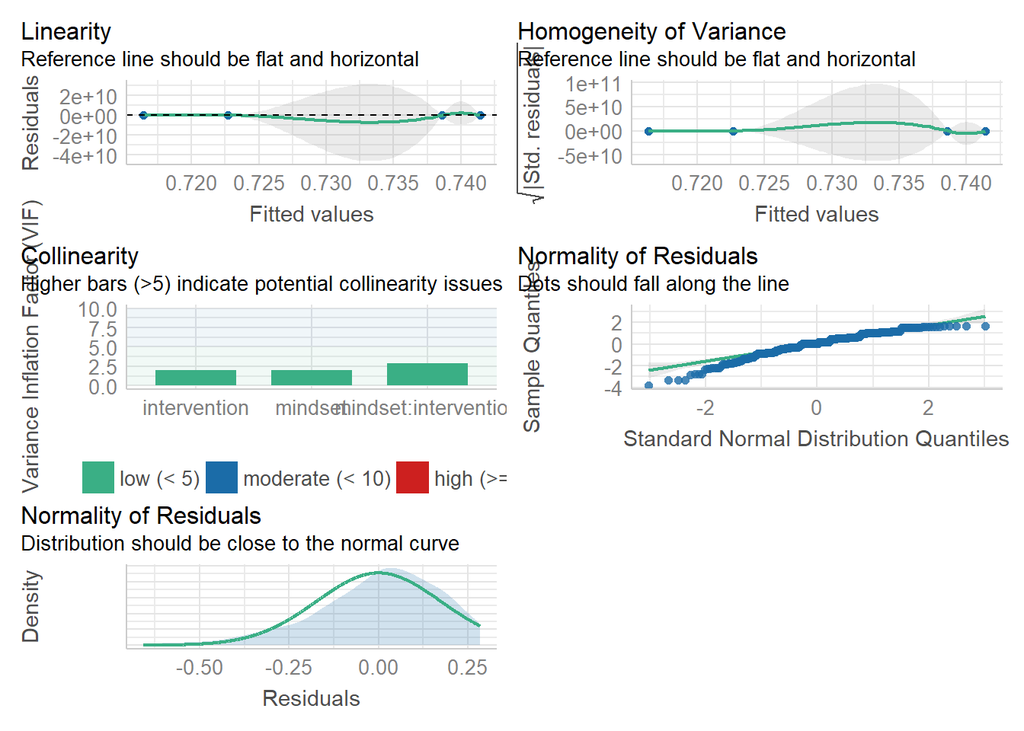

```r
check_model(iq_mod,
            check = c("vif", "qq", "normality", "ncv", "homogeneity", "reqq"))
```

```r
report(iq_mod) %>%
  summary()
```

```
## 'interpret_d()' is now deprecated. Please use 'interpret_cohens_d()'.
## 'interpret_d()' is now deprecated. Please use 'interpret_cohens_d()'.
```

We fitted a linear model to predict iq_real with mindset and intervention. The model’s explanatory power is very weak (R2 = 3.57e-03, adj. R2 = -4.32e-03). The model’s intercept is at 0.74 (95% CI [0.70, 0.78]). Within this model:

- The effect of mindset [Growth] is statistically non-significant and negative (beta = -0.02, 95% CI [-0.07, 0.03], t(379) = -0.62, p = 0.533, Std. beta = -0.09)
- The effect of intervention [Mindfulness] is statistically non-significant and positive (beta = 2.83e-03, 95% CI [-0.05, 0.05], t(379) = 0.11, p = 0.911, Std. beta = 0.02)
- The interaction effect of intervention [Mindfulness] on mindset [Growth] is statistically non-significant and negative (beta = -9.11e-03, 95% CI [-0.08, 0.06], t(379) = -0.25, p = 0.800, Std. beta = -0.05)

# Secondary outcomes

## Task enjoyment/boredom

```r
bored_mod <- lm(out_2 ~ mindset * intervention,
                data = processed_final)

tab_model(bored_mod,
          dv.labels = "Boredom",
          show.stat = TRUE,
          show.est = FALSE,
          show.std = TRUE,
          show.fstat = TRUE,
          file = here::here("docs/boredom.html")
          )
```

|  | Boredom |  |  |  |
| --- | --- | --- | --- | --- |
| Predictors | std. Beta | standardized CI | Statistic | p |
| (Intercept) | -0.02 | -0.23 – 0.18 | -0.22 | 0.824 |
| mindset [Growth] | 0.10 | -0.19 – 0.38 | 0.67 | 0.500 |
| intervention [Mindfulness] | 0.00 | -0.28 – 0.29 | 0.01 | 0.991 |
| mindset [Growth] * intervention [Mindfulness] | -0.11 | -0.52 – 0.29 | -0.54 | 0.587 |
| Observations | 383 |  |  |  |
| R<sup>2</sup> / R<sup>2</sup> adjusted | 0.002 / -0.006 |  |  |  |

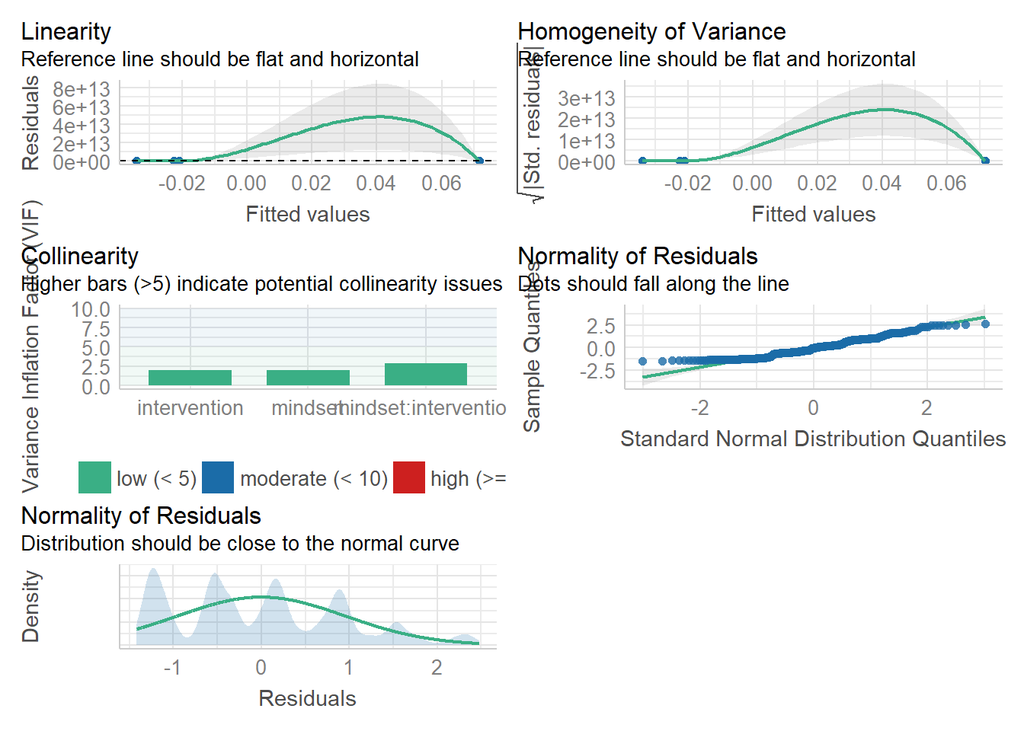

```r
check_model(bored_mod,
            check = c("vif", "qq", "normality", "ncv", "homogeneity", "reqq"))
```

```r
report(bored_mod) %>%
  summary()
```

```
## 'interpret_d()' is now deprecated. Please use 'interpret_cohens_d()'.
## 'interpret_d()' is now deprecated. Please use 'interpret_cohens_d()'.
```

We fitted a linear model to predict out_2 with mindset and intervention. The model’s explanatory power is very weak (R2 = 2.02e-03, adj. R2 = -5.88e-03). The model’s intercept is at -0.02 (95% CI [-0.22, 0.18]). Within this model:

- The effect of mindset [Growth] is statistically non-significant and positive (beta = 0.09, 95% CI [-0.18, 0.37], t(379) = 0.67, p = 0.500, Std. beta = 0.10)
- The effect of intervention [Mindfulness] is statistically non-significant and positive (beta = 1.56e-03, 95% CI [-0.27, 0.28], t(379) = 0.01, p = 0.991, Std. beta = 1.62e-03)
- The interaction effect of intervention [Mindfulness] on mindset [Growth] is statistically non-significant and negative (beta = -0.11, 95% CI [-0.50, 0.28], t(379) = -0.54, p = 0.587, Std. beta = -0.11)

## Anxiety/stress

```r
stress_mod <- lm(out_1 ~ mindset * intervention,
                 data = processed_final)

tab_model(stress_mod,
          # bootstrap = TRUE,
          dv.labels = "Stress/anxiety",
          show.stat = TRUE,
          show.est = FALSE,
          show.std = TRUE,
          show.fstat = TRUE,
        file = here::here("docs/anxiety.html")
        )
```

|  | Stress/anxiety |  |  |  |
| --- | --- | --- | --- | --- |
| Predictors | std. Beta | standardized CI | Statistic | p |
| (Intercept) | 0.13 | -0.08 – 0.33 | 1.21 | 0.226 |
| mindset [Growth] | -0.24 | -0.52 – 0.05 | -1.63 | 0.104 |
| intervention [Mindfulness] | -0.21 | -0.49 – 0.08 | -1.44 | 0.152 |
| mindset [Growth] * intervention [Mindfulness] | 0.40 | -0.00 – 0.80 | 1.96 | 0.051 |
| Observations | 383 |  |  |  |
| R<sup>2</sup> / R<sup>2</sup> adjusted | 0.010 / 0.002 |  |  |  |

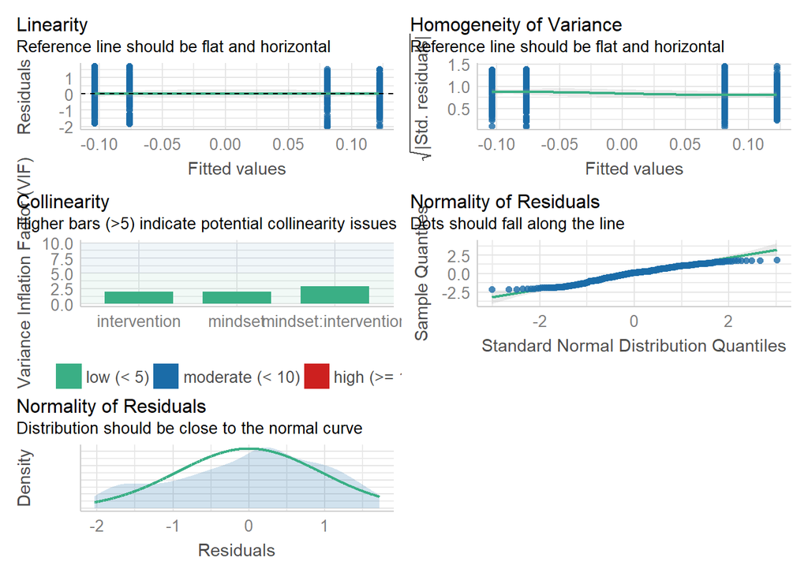

```r
check_model(stress_mod,
            check = c("vif", "qq", "normality", "ncv", "homogeneity", "reqq"))
```

```r
report(stress_mod) %>%
  summary()
```

```
## 'interpret_d()' is now deprecated. Please use 'interpret_cohens_d()'.
## 'interpret_d()' is now deprecated. Please use 'interpret_cohens_d()'.
```

We fitted a linear model to predict out_1 with mindset and intervention. The model’s explanatory power is very weak (R2 = 0.01, adj. R2 = 2.48e-03). The model’s intercept is at 0.12 (95% CI [-0.08, 0.32]). Within this model:

- The effect of mindset [Growth] is statistically non-significant and negative (beta = -0.23, 95% CI [-0.50, 0.05], t(379) = -1.63, p = 0.104, Std. beta = -0.24)
- The effect of intervention [Mindfulness] is statistically non-significant and negative (beta = -0.20, 95% CI [-0.47, 0.07], t(379) = -1.44, p = 0.152, Std. beta = -0.21)
- The interaction effect of intervention [Mindfulness] on mindset [Growth] is statistically non-significant and positive (beta = 0.38, 95% CI [-1.92e-03, 0.77], t(379) = 1.96, p = 0.051, Std. beta = 0.40)

## Achievement goals

None of the achievement goal variables were associated with the manipulated variables.

```r
ag_mod <-
  processed_final %>%
  select(response_id, agq_sap:agt_p_tav, mindset, intervention, extra_tasks) %>%
  pivot_longer(agq_sap:agt_p_tav) %>%
  mutate(value = if_else(str_detect(name, "_p_") & extra_tasks == 0,
                         NA_real_,
                         value)) %>%
  drop_na(value) %>%
  group_nest(name) %>%
  mutate(model = map(data,
                     ~lm(value ~ mindset * intervention,
                         data = .x)))

pull(ag_mod, model) %>%
  set_names(ag_mod$name) %>%
  tab_model(.,
            dv.labels = ag_mod$name,
            show.stat = TRUE,
            show.est = FALSE,
            show.std = TRUE,
            show.fstat = TRUE)
```

|  | agq_oap |  |  |  | agq_oav |  |  |  | agq_sap |  |  |  | agq_sav |  |  |  | agq_tap |  |  |  | agq_tav |  |  |  | agt_p_oap |  |  |  | agt_p_oav | … |
| --- | --- | --- | --- | --- | --- | --- | --- | --- | --- | --- | --- | --- | --- | --- | --- | --- | --- | --- | --- | --- | --- | --- | --- | --- | --- | --- | --- | --- | --- | --- |
| Predictors | std. Beta | standardized CI | Statistic | p | std. Beta | standardized CI | Statistic | p | std. Beta | standardized CI | Statistic | p | std. Beta | standardized CI | Statistic | p | std. Beta | standardized CI | Statistic | p | std. Beta | standardized CI | Statistic | p | std. Beta | standardized CI | Statistic | p | std. Beta | … |
| (Intercept) | 0.06 | -0.14 – 0.27 | 19.23 | **<0.001** | -0.05 | -0.26 – 0.15 | 22.02 | **<0.001** | 0.03 | -0.18 – 0.23 | 28.06 | **<0.001** | -0.01 | -0.22 – 0.19 | 38.54 | **<0.001** | -0.12 | -0.32 – 0.09 | 42.54 | **<0.001** | -0.10 | -0.31 – 0.11 | 28.68 | **<0.001** | 0.03 | -0.23 – 0.29 | 14.98 | **<0.001** | -0.01 | … |
| mindset [Growth] | -0.20 | -0.49 – 0.08 | -1.39 | 0.164 | -0.04 | -0.32 – 0.25 | -0.25 | 0.800 | -0.14 | -0.43 – 0.14 | -0.98 | 0.328 | -0.09 | -0.37 – 0.20 | -0.60 | 0.549 | 0.15 | -0.14 – 0.43 | 1.02 | 0.308 | 0.03 | -0.25 – 0.32 | 0.22 | 0.829 | -0.19 | -0.55 – 0.16 | -1.09 | 0.277 | -0.12 | … |
| intervention [Mindfulness] | -0.01 | -0.29 – 0.28 | -0.06 | 0.954 | 0.07 | -0.22 – 0.35 | 0.45 | 0.650 | -0.02 | -0.30 – 0.27 | -0.11 | 0.909 | 0.04 | -0.25 – 0.32 | 0.25 | 0.805 | 0.23 | -0.06 – 0.51 | 1.57 | 0.116 | 0.20 | -0.09 – 0.48 | 1.36 | 0.174 | -0.08 | -0.44 – 0.28 | -0.44 | 0.663 | -0.06 | … |
| mindset [Growth] * intervention [Mindfulness] | 0.17 | -0.23 – 0.58 | 0.85 | 0.395 | 0.17 | -0.24 – 0.57 | 0.82 | 0.414 | 0.22 | -0.18 – 0.63 | 1.09 | 0.276 | 0.17 | -0.24 – 0.57 | 0.81 | 0.420 | -0.30 | -0.70 – 0.10 | -1.47 | 0.143 | -0.07 | -0.47 – 0.34 | -0.33 | 0.745 | 0.46 | -0.04 – 0.96 | 1.80 | 0.073 | 0.45 | … |
| Observations | 383 |  |  |  | 383 |  |  |  | 383 |  |  |  | 383 |  |  |  | 383 |  |  |  | 383 |  |  |  | 247 |  |  |  | 247 | … |
| R<sup>2</sup> / R<sup>2</sup> adjusted | 0.007 / -0.001 |  |  |  | 0.008 / -0.000 |  |  |  | 0.006 / -0.002 |  |  |  | 0.005 / -0.003 |  |  |  | 0.007 / -0.001 |  |  |  | 0.007 / -0.001 |  |  |  | 0.019 / 0.007 |  |  |  | 0.022 / 0.010 | … |

# Moderator effects

The primary outcomes are checked for moderator effects (the upper row means the name of the moderator, that is used in the table as “value”).

## Number of solved optional exercises

```r
moderators_m1 <-
  processed_final %>%
  select(response_id, extra_tasks, mindset, intervention,
         age, gender, education,
         ms_mean:grit_mean) %>%
  # Scale all continuous predictors
  mutate(across(ms_mean:grit_mean, scale)) %>%
  pivot_longer(cols = c(age, ms_mean:grit_mean)) %>%
  group_nest(name) %>%
  mutate(model = map(data,
                     ~zeroinfl(extra_tasks ~ mindset * intervention * value,
                      dist = "negbin",
                      data = .x)))


pull(moderators_m1, model) %>%
  set_names(moderators_m1$name) %>%
  tab_model(.,
            dv.labels = moderators_m1$name,
            show.aic = TRUE,
            show.stat = TRUE,
            p.style = "numeric",
            show.loglik = TRUE,
            show.dev = TRUE,
            show.zeroinf = TRUE,
            file = here::here("docs/moderators.html")
          )
```

|  | age |  |  |  | cams_mean |  |  |  | grit_mean |  |  |  | ms_mean |  |  |  | risc_mean |  |  |  | sc_mean |  |  |  | se_mean |  |  |  |
| --- | --- | --- | --- | --- | --- | --- | --- | --- | --- | --- | --- | --- | --- | --- | --- | --- | --- | --- | --- | --- | --- | --- | --- | --- | --- | --- | --- | --- |
| Predictors | Incidence Rate Ratios | CI | Statistic | p | Incidence Rate Ratios | CI | Statistic | p | Incidence Rate Ratios | CI | Statistic | p | Incidence Rate Ratios | CI | Statistic | p | Incidence Rate Ratios | CI | Statistic | p | Incidence Rate Ratios | CI | Statistic | p | Incidence Rate Ratios | CI | Statistic | p |
| (Intercept) | 4.09 | 0.38 – 44.43 | 1.16 | 0.247 | 4.12 | 3.08 – 5.50 | 9.60 | **<0.001** | 4.30 | 3.24 – 5.71 | 10.11 | **<0.001** | 4.21 | 3.17 – 5.58 | 9.95 | **<0.001** | 4.23 | 3.19 – 5.62 | 10.01 | **<0.001** | 4.21 | 3.18 – 5.58 | 10.00 | **<0.001** | 4.30 | 3.23 – 5.71 | 10.06 | **<0.001** |
| mindset [Growth] | 1.51 | 0.11 – 19.96 | 0.31 | 0.755 | 1.26 | 0.86 – 1.83 | 1.20 | 0.232 | 1.21 | 0.84 – 1.75 | 1.04 | 0.300 | 1.22 | 0.84 – 1.76 | 1.06 | 0.289 | 1.23 | 0.86 – 1.78 | 1.12 | 0.261 | 1.22 | 0.84 – 1.75 | 1.05 | 0.295 | 1.24 | 0.86 – 1.78 | 1.14 | 0.256 |
| intervention [Mindfulness] | 0.62 | 0.04 – 9.05 | -0.35 | 0.724 | 1.02 | 0.69 – 1.49 | 0.08 | 0.938 | 1.00 | 0.69 – 1.46 | 0.02 | 0.987 | 0.96 | 0.66 – 1.40 | -0.22 | 0.826 | 0.99 | 0.68 – 1.43 | -0.07 | 0.945 | 1.02 | 0.70 – 1.47 | 0.08 | 0.934 | 0.94 | 0.64 – 1.36 | -0.35 | 0.724 |
| value | 1.00 | 0.90 – 1.12 | 0.03 | 0.978 | 0.89 | 0.67 – 1.18 | -0.83 | 0.409 | 1.04 | 0.74 – 1.45 | 0.21 | 0.830 | 0.92 | 0.71 – 1.19 | -0.63 | 0.529 | 1.01 | 0.76 – 1.33 | 0.04 | 0.965 | 0.91 | 0.72 – 1.14 | -0.85 | 0.393 | 0.94 | 0.71 – 1.25 | -0.40 | 0.693 |
| mindset [Growth] * intervention [Mindfulness] | 0.96 | 0.04 – 21.05 | -0.03 | 0.977 | 0.79 | 0.47 – 1.34 | -0.86 | 0.391 | 0.89 | 0.53 – 1.49 | -0.45 | 0.656 | 0.93 | 0.55 – 1.57 | -0.26 | 0.791 | 0.89 | 0.53 – 1.51 | -0.42 | 0.674 | 0.88 | 0.53 – 1.49 | -0.46 | 0.646 | 0.94 | 0.56 – 1.57 | -0.25 | 0.803 |
| mindset [Growth] * value | 0.99 | 0.88 – 1.11 | -0.15 | 0.884 | 1.01 | 0.70 – 1.46 | 0.07 | 0.946 | 0.89 | 0.60 – 1.34 | -0.55 | 0.585 | 1.27 | 0.88 – 1.83 | 1.28 | 0.201 | 1.01 | 0.71 – 1.44 | 0.08 | 0.936 | 0.93 | 0.66 – 1.31 | -0.40 | 0.687 | 1.04 | 0.72 – 1.49 | 0.20 | 0.844 |
| intervention [Mindfulness] * value | 1.02 | 0.90 – 1.15 | 0.33 | 0.739 | 1.49 | 1.05 – 2.11 | 2.24 | **0.025** | 0.89 | 0.60 – 1.31 | -0.60 | 0.546 | 0.93 | 0.66 – 1.30 | -0.42 | 0.671 | 1.29 | 0.89 – 1.86 | 1.34 | 0.181 | 1.24 | 0.90 – 1.71 | 1.30 | 0.195 | 1.48 | 1.03 – 2.13 | 2.13 | **0.033** |
| (mindset [Growth] intervention [Mindfulness]) value | 1.00 | 0.87 – 1.14 | -0.05 | 0.963 | 0.99 | 0.59 – 1.67 | -0.04 | 0.971 | 1.15 | 0.68 – 1.95 | 0.52 | 0.604 | 1.04 | 0.63 – 1.70 | 0.15 | 0.879 | 0.78 | 0.46 – 1.30 | -0.96 | 0.336 | 0.97 | 0.60 – 1.58 | -0.11 | 0.912 | 0.70 | 0.42 – 1.15 | -1.42 | 0.155 |
| Zero-Inflated Model |  |  |  |  |  |  |  |  |  |  |  |  |  |  |  |  |  |  |  |  |  |  |  |  |  |  |  |  |
| (Intercept) | 0.00 | 0.00 – 1.15 | -1.91 | 0.056 | 0.24 | 0.10 – 0.61 | -3.02 | **0.002** | 0.27 | 0.12 – 0.62 | -3.08 | **0.002** | 0.27 | 0.11 – 0.62 | -3.06 | **0.002** | 0.27 | 0.11 – 0.63 | -3.02 | **0.003** | 0.27 | 0.12 – 0.62 | -3.08 | **0.002** | 0.29 | 0.13 – 0.64 | -3.06 | **0.002** |
| mindset [Growth] | 476.46 | 0.43 – 527339.79 | 1.72 | 0.085 | 1.07 | 0.37 – 3.15 | 0.13 | 0.896 | 1.05 | 0.39 – 2.83 | 0.10 | 0.920 | 0.96 | 0.34 – 2.73 | -0.08 | 0.936 | 1.05 | 0.39 – 2.83 | 0.09 | 0.927 | 1.01 | 0.37 – 2.76 | 0.03 | 0.978 | 1.00 | 0.38 – 2.61 | 0.00 | 0.996 |
| intervention [Mindfulness] | 217.02 | 0.20 – 237804.07 | 1.51 | 0.132 | 1.06 | 0.34 – 3.25 | 0.10 | 0.921 | 0.99 | 0.34 – 2.87 | -0.02 | 0.983 | 1.04 | 0.37 – 2.93 | 0.08 | 0.935 | 1.02 | 0.36 – 2.89 | 0.03 | 0.973 | 1.04 | 0.37 – 2.93 | 0.07 | 0.945 | 0.98 | 0.36 – 2.65 | -0.05 | 0.961 |
| value | 1.22 | 0.95 – 1.57 | 1.54 | 0.123 | 0.89 | 0.40 – 1.96 | -0.30 | 0.764 | 1.04 | 0.44 – 2.44 | 0.08 | 0.933 | 1.01 | 0.46 – 2.24 | 0.04 | 0.972 | 1.17 | 0.51 – 2.65 | 0.37 | 0.714 | 0.94 | 0.50 – 1.76 | -0.20 | 0.838 | 1.16 | 0.54 – 2.48 | 0.37 | 0.709 |
| mindset [Growth] * intervention [Mindfulness] | 0.00 | 0.00 – 19.46 | -1.30 | 0.193 | 0.05 | 0.00 – 4.11 | -1.34 | 0.180 | 0.91 | 0.21 – 3.99 | -0.13 | 0.896 | 1.07 | 0.25 – 4.55 | 0.09 | 0.930 | 1.00 | 0.24 – 4.15 | -0.00 | 0.997 | 0.97 | 0.23 – 4.15 | -0.03 | 0.973 | 1.02 | 0.25 – 4.10 | 0.02 | 0.981 |
| mindset [Growth] * value | 0.76 | 0.56 – 1.03 | -1.75 | 0.080 | 0.92 | 0.33 – 2.56 | -0.15 | 0.880 | 0.94 | 0.32 – 2.76 | -0.11 | 0.915 | 1.49 | 0.50 – 4.43 | 0.72 | 0.473 | 0.85 | 0.32 – 2.26 | -0.33 | 0.741 | 1.37 | 0.54 – 3.47 | 0.67 | 0.501 | 1.03 | 0.40 – 2.66 | 0.06 | 0.949 |
| intervention [Mindfulness] * value | 0.79 | 0.58 – 1.07 | -1.54 | 0.124 | 1.96 | 0.71 – 5.39 | 1.30 | 0.193 | 0.49 | 0.16 – 1.44 | -1.31 | 0.192 | 1.08 | 0.40 – 2.95 | 0.15 | 0.881 | 1.31 | 0.45 – 3.80 | 0.50 | 0.619 | 1.77 | 0.72 – 4.34 | 1.24 | 0.213 | 1.16 | 0.44 – 3.04 | 0.29 | 0.769 |
| (mindset [Growth] intervention [Mindfulness]) value | 1.30 | 0.88 – 1.92 | 1.31 | 0.191 | 20.14 | 0.49 – 831.64 | 1.58 | 0.114 | 0.99 | 0.22 – 4.40 | -0.01 | 0.994 | 0.71 | 0.17 – 2.90 | -0.48 | 0.629 | 1.12 | 0.27 – 4.60 | 0.15 | 0.880 | 0.66 | 0.17 – 2.53 | -0.60 | 0.548 | 1.08 | 0.27 – 4.29 | 0.11 | 0.911 |
| Observations | 383 |  |  |  | 383 |  |  |  | 381 |  |  |  | 383 |  |  |  | 383 |  |  |  | 383 |  |  |  | 381 |  |  |  |
| R<sup>2</sup> / R<sup>2</sup> adjusted | 0.209 / 0.192 |  |  |  | 0.302 / 0.287 |  |  |  | 0.158 / 0.140 |  |  |  | 0.222 / 0.205 |  |  |  | 0.167 / 0.149 |  |  |  | 0.263 / 0.247 |  |  |  | 0.276 / 0.261 |  |  |  |
| AIC | 1825.610 |  |  |  | 1810.643 |  |  |  | 1814.851 |  |  |  | 1825.030 |  |  |  | 1824.660 |  |  |  | 1823.051 |  |  |  | 1814.207 |  |  |  |
| log-Likelihood | -895.805 |  |  |  | -888.321 |  |  |  | -890.425 |  |  |  | -895.515 |  |  |  | -895.330 |  |  |  | -894.526 |  |  |  | -890.103 |  |  |  |

Those who had a higher dispositional mindfulness or had higher self-esteem, and received the mindfulness induction solved approximately 1.5 times more optional tasks, compared to those who were in the fixed mindset and control conditions.

```r
tab_model(moderators_m1$model[c(2, 7)],
          dv.labels = c("Dispositional mindfulness",
                        "Self-esteem"),
          # bootstrap = TRUE,
          show.aic = TRUE,
          show.stat = TRUE,
          p.style = "numeric",
          show.loglik = TRUE,
          show.dev = TRUE,
          # file = here::here("docs/moderators.html"),
          show.zeroinf = TRUE)
```

|  | Dispositional mindfulness |  |  |  | Self-esteem |  |  |  |
| --- | --- | --- | --- | --- | --- | --- | --- | --- |
| Predictors | Incidence Rate Ratios | CI | Statistic | p | Incidence Rate Ratios | CI | Statistic | p |
| (Intercept) | 4.12 | 3.08 – 5.50 | 9.60 | **<0.001** | 4.30 | 3.23 – 5.71 | 10.06 | **<0.001** |
| mindset [Growth] | 1.26 | 0.86 – 1.83 | 1.20 | 0.232 | 1.24 | 0.86 – 1.78 | 1.14 | 0.256 |
| intervention [Mindfulness] | 1.02 | 0.69 – 1.49 | 0.08 | 0.938 | 0.94 | 0.64 – 1.36 | -0.35 | 0.724 |
| value | 0.89 | 0.67 – 1.18 | -0.83 | 0.409 | 0.94 | 0.71 – 1.25 | -0.40 | 0.693 |
| mindset [Growth] * intervention [Mindfulness] | 0.79 | 0.47 – 1.34 | -0.86 | 0.391 | 0.94 | 0.56 – 1.57 | -0.25 | 0.803 |
| mindset [Growth] * value | 1.01 | 0.70 – 1.46 | 0.07 | 0.946 | 1.04 | 0.72 – 1.49 | 0.20 | 0.844 |
| intervention [Mindfulness] * value | 1.49 | 1.05 – 2.11 | 2.24 | **0.025** | 1.48 | 1.03 – 2.13 | 2.13 | **0.033** |
| (mindset [Growth] intervention [Mindfulness]) value | 0.99 | 0.59 – 1.67 | -0.04 | 0.971 | 0.70 | 0.42 – 1.15 | -1.42 | 0.155 |
| Zero-Inflated Model |  |  |  |  |  |  |  |  |
| (Intercept) | 0.24 | 0.10 – 0.61 | -3.02 | **0.002** | 0.29 | 0.13 – 0.64 | -3.06 | **0.002** |
| mindset [Growth] | 1.07 | 0.37 – 3.15 | 0.13 | 0.896 | 1.00 | 0.38 – 2.61 | 0.00 | 0.996 |
| intervention [Mindfulness] | 1.06 | 0.34 – 3.25 | 0.10 | 0.921 | 0.98 | 0.36 – 2.65 | -0.05 | 0.961 |
| value | 0.89 | 0.40 – 1.96 | -0.30 | 0.764 | 1.16 | 0.54 – 2.48 | 0.37 | 0.709 |
| mindset [Growth] * intervention [Mindfulness] | 0.05 | 0.00 – 4.11 | -1.34 | 0.180 | 1.02 | 0.25 – 4.10 | 0.02 | 0.981 |
| mindset [Growth] * value | 0.92 | 0.33 – 2.56 | -0.15 | 0.880 | 1.03 | 0.40 – 2.66 | 0.06 | 0.949 |
| intervention [Mindfulness] * value | 1.96 | 0.71 – 5.39 | 1.30 | 0.193 | 1.16 | 0.44 – 3.04 | 0.29 | 0.769 |
| (mindset [Growth] intervention [Mindfulness]) value | 20.14 | 0.49 – 831.64 | 1.58 | 0.114 | 1.08 | 0.27 – 4.29 | 0.11 | 0.911 |
| Observations | 383 |  |  |  | 381 |  |  |  |
| R<sup>2</sup> / R<sup>2</sup> adjusted | 0.302 / 0.287 |  |  |  | 0.276 / 0.261 |  |  |  |
| AIC | 1810.643 |  |  |  | 1814.207 |  |  |  |
| log-Likelihood | -888.321 |  |  |  | -890.103 |  |  |  |

```r
BIC(moderators_m1$model[[2]])
```

```
## [1] 1877.759
```

```r
BIC(moderators_m1$model[[4]])
```

```
## [1] 1892.147
```

```r
# BF for full model with interaction term
exp((BIC(mod_0) - BIC(moderators_m1$model[[2]]))/2)
```

```
## [1] 5.8834e-14
```

```r
tab_model(
          mod_5,
          moderators_m1$model[[2]],
          # bootstrap = TRUE,
          dv.labels = c("Simple model",
                        "Moderator model"),
          show.aic = TRUE,
          show.stat = TRUE,
          p.style = "numeric",
          show.loglik = TRUE,
          show.dev = TRUE,
          show.fstat = TRUE,
          show.zeroinf = TRUE
          # file = here::here("docs/zinb-mod.html")
          )
```

|  | Simple model |  |  |  | Moderator model |  |  |  |
| --- | --- | --- | --- | --- | --- | --- | --- | --- |
| Predictors | Incidence Rate Ratios | CI | Statistic | p | Incidence Rate Ratios | CI | Statistic | p |
| (Intercept) | 4.17 | 3.12 – 5.58 | 9.64 | **<0.001** | 4.12 | 3.08 – 5.50 | 9.60 | **<0.001** |
| mindset [Growth] | 1.24 | 0.85 – 1.80 | 1.13 | 0.260 | 1.26 | 0.86 – 1.83 | 1.20 | 0.232 |
| intervention [Mindfulness] | 0.99 | 0.68 – 1.45 | -0.03 | 0.976 | 1.02 | 0.69 – 1.49 | 0.08 | 0.938 |
| mindset [Growth] * intervention [Mindfulness] | 0.88 | 0.52 – 1.50 | -0.47 | 0.642 | 0.79 | 0.47 – 1.34 | -0.86 | 0.391 |
| value |  |  |  |  | 0.89 | 0.67 – 1.18 | -0.83 | 0.409 |
| mindset [Growth] * value |  |  |  |  | 1.01 | 0.70 – 1.46 | 0.07 | 0.946 |
| intervention [Mindfulness] * value |  |  |  |  | 1.49 | 1.05 – 2.11 | 2.24 | **0.025** |
| (mindset [Growth] intervention [Mindfulness]) value |  |  |  |  | 0.99 | 0.59 – 1.67 | -0.04 | 0.971 |
| Zero-Inflated Model |  |  |  |  |  |  |  |  |
| (Intercept) | 0.25 | 0.10 – 0.62 | -2.98 | **0.003** | 0.24 | 0.10 – 0.61 | -3.02 | **0.002** |
| mindset [Growth] | 1.05 | 0.37 – 2.98 | 0.10 | 0.923 | 1.07 | 0.37 – 3.15 | 0.13 | 0.896 |
| intervention [Mindfulness] | 1.06 | 0.36 – 3.09 | 0.11 | 0.915 | 1.06 | 0.34 – 3.25 | 0.10 | 0.921 |
| mindset [Growth] * intervention [Mindfulness] | 0.96 | 0.22 – 4.18 | -0.05 | 0.962 | 0.05 | 0.00 – 4.11 | -1.34 | 0.180 |
| value |  |  |  |  | 0.89 | 0.40 – 1.96 | -0.30 | 0.764 |
| mindset [Growth] * value |  |  |  |  | 0.92 | 0.33 – 2.56 | -0.15 | 0.880 |
| intervention [Mindfulness] * value |  |  |  |  | 1.96 | 0.71 – 5.39 | 1.30 | 0.193 |
| (mindset [Growth] intervention [Mindfulness]) value |  |  |  |  | 20.14 | 0.49 – 831.64 | 1.58 | 0.114 |
| Observations | 383 |  |  |  | 383 |  |  |  |
| R<sup>2</sup> / R<sup>2</sup> adjusted | 0.103 / 0.094 |  |  |  | 0.302 / 0.287 |  |  |  |
| AIC | 1814.971 |  |  |  | 1810.643 |  |  |  |
| log-Likelihood | -898.486 |  |  |  | -888.321 |  |  |  |

### Visualize moderator effect

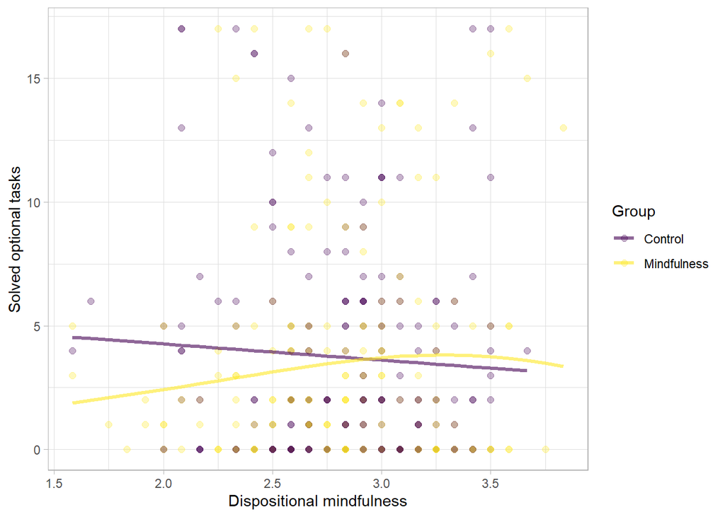

```r
cams_mod <-
  zeroinfl(extra_tasks ~ intervention * scale(cams_mean),
           dist = "negbin",
           data = processed_final)

mod_plot <-
  processed_final %>%
  mutate(.fitted = predict(cams_mod, type = "response")) %>%
  ggplot() +
  aes(x = cams_mean, y = extra_tasks, color = intervention) +
  geom_point(alpha = .3, size = 2) +
  geom_line(aes(y = .fitted), alpha = .6, size = 1.2) +
  scale_color_viridis_d() +
  labs(color = "Group",
       y = "Solved optional tasks",
       x = "Dispositional mindfulness")

mod_plot
```

```r
# ggsave(plot = mod_plot, filename = "docs/figure_4.png", dpi = 300)
```

## Number of correct answers in the “real” IQ test

Here we only found that the score on the “real” IQ test was weakly associated with the grit score (the upper row means the name of the moderator, that is used in the table as “value”).

```r
moderators_m2 <-
  processed_final %>%
  select(response_id, mindset, intervention,
         iq_real,
         age, ms_mean:grit_mean) %>%
  # Scale all continuous predictors
  mutate(across(c(iq_real, ms_mean:grit_mean), scale)) %>%
  pivot_longer(cols = c(age, ms_mean:grit_mean)) %>%
  group_nest(name) %>%
  mutate(model = map(data,
                     ~lm(iq_real ~ mindset * intervention * value,
                      data = .x)))


pull(moderators_m2, model) %>%
  set_names(moderators_m2$name) %>%
  tab_model(.,
            dv.labels = moderators_m2$name,
            show.stat = TRUE,
            show.est = FALSE,
            show.std = TRUE,
            show.fstat = TRUE)
```

|  | age |  |  |  |  |  | cams_mean |  |  |  | grit_mean |  |  |  | ms_mean |  |  |  | risc_mean |  |  |  | sc_mean |  |  |  | se_mean |  |  | … |
| --- | --- | --- | --- | --- | --- | --- | --- | --- | --- | --- | --- | --- | --- | --- | --- | --- | --- | --- | --- | --- | --- | --- | --- | --- | --- | --- | --- | --- | --- | --- |
| Predictors | std. Beta | standardized CI | Statistic | std. Statistic | p | std. p | std. Beta | standardized CI | Statistic | p | std. Beta | standardized CI | Statistic | p | std. Beta | standardized CI | Statistic | p | std. Beta | standardized CI | Statistic | p | std. Beta | standardized CI | Statistic | p | std. Beta | standardized CI | Statistic | … |
| (Intercept) | 0.06 | -0.15 – 0.27 | -0.53 | 0.55 | 0.594 | 0.579 | 0.05 | -0.16 – 0.25 | 0.43 | 0.670 | 0.05 | -0.16 – 0.26 | 0.54 | 0.588 | 0.05 | -0.16 – 0.26 | 0.48 | 0.633 | 0.05 | -0.16 – 0.26 | 0.48 | 0.629 | 0.05 | -0.16 – 0.26 | 0.47 | 0.640 | 0.10 | -0.11 – 0.32 | 1.04 | … |
| mindset [Growth] | -0.09 | -0.37 – 0.20 | 1.00 | -0.59 | 0.317 | 0.557 | -0.09 | -0.38 – 0.20 | -0.62 | 0.535 | -0.10 | -0.38 – 0.19 | -0.67 | 0.502 | -0.07 | -0.35 – 0.22 | -0.46 | 0.642 | -0.08 | -0.37 – 0.20 | -0.57 | 0.566 | -0.09 | -0.38 – 0.20 | -0.62 | 0.538 | -0.15 | -0.44 – 0.14 | -0.99 | … |
| intervention [Mindfulness] | 0.00 | -0.28 – 0.29 | 1.29 | 0.03 | 0.199 | 0.974 | 0.03 | -0.26 – 0.31 | 0.18 | 0.857 | 0.01 | -0.28 – 0.30 | 0.07 | 0.947 | 0.01 | -0.27 – 0.30 | 0.10 | 0.918 | 0.01 | -0.27 – 0.30 | 0.10 | 0.922 | 0.02 | -0.27 – 0.30 | 0.11 | 0.914 | -0.05 | -0.34 – 0.24 | -0.33 | … |
| value | 0.11 | -0.26 – 0.48 | 0.59 | 0.59 | 0.558 | 0.558 | -0.13 | -0.35 – 0.09 | -1.18 | 0.238 | 0.22 | 0.00 – 0.44 | 1.99 | **0.047** | -0.09 | -0.30 – 0.12 | -0.83 | 0.407 | 0.04 | -0.15 – 0.24 | 0.44 | 0.659 | -0.02 | -0.22 – 0.19 | -0.16 | 0.872 | 0.08 | -0.14 – 0.31 | 0.74 | … |
| mindset [Growth] * intervention [Mindfulness] | -0.06 | -0.46 – 0.35 | -1.23 | -0.29 | 0.221 | 0.776 | -0.06 | -0.47 – 0.34 | -0.31 | 0.755 | -0.04 | -0.44 – 0.36 | -0.20 | 0.845 | -0.08 | -0.48 – 0.33 | -0.38 | 0.701 | -0.06 | -0.46 – 0.35 | -0.27 | 0.786 | -0.05 | -0.46 – 0.35 | -0.26 | 0.794 | 0.00 | -0.40 – 0.41 | 0.02 | … |
| mindset [Growth] * value | -0.22 | -0.63 – 0.18 | -1.08 | -1.08 | 0.281 | 0.281 | 0.19 | -0.10 – 0.49 | 1.28 | 0.202 | -0.18 | -0.47 – 0.12 | -1.18 | 0.238 | -0.10 | -0.40 – 0.20 | -0.64 | 0.521 | -0.10 | -0.37 – 0.17 | -0.75 | 0.454 | -0.10 | -0.39 – 0.20 | -0.65 | 0.516 | -0.16 | -0.46 – 0.14 | -1.06 | … |
| intervention [Mindfulness] * value | -0.27 | -0.68 – 0.15 | -1.28 | -1.28 | 0.203 | 0.203 | 0.20 | -0.08 – 0.48 | 1.42 | 0.156 | -0.07 | -0.35 – 0.21 | -0.50 | 0.618 | 0.09 | -0.19 – 0.37 | 0.62 | 0.538 | -0.04 | -0.33 – 0.25 | -0.25 | 0.800 | 0.01 | -0.27 – 0.29 | 0.07 | 0.941 | -0.01 | -0.31 – 0.28 | -0.09 | … |
| (mindset [Growth] intervention [Mindfulness]) value | 0.29 | -0.19 – 0.78 | 1.19 | 1.19 | 0.236 | 0.236 | -0.15 | -0.56 – 0.26 | -0.71 | 0.478 | 0.19 | -0.22 – 0.59 | 0.91 | 0.365 | -0.02 | -0.42 – 0.39 | -0.08 | 0.936 | 0.14 | -0.28 – 0.55 | 0.65 | 0.517 | 0.19 | -0.22 – 0.60 | 0.93 | 0.355 | 0.10 | -0.31 – 0.51 | 0.49 | … |
| Observations | 383 |  |  |  |  |  | 383 |  |  |  | 381 |  |  |  | 383 |  |  |  | 383 |  |  |  | 383 |  |  |  | 381 |  |  | … |
| R<sup>2</sup> / R<sup>2</sup> adjusted | 0.018 / -0.000 |  |  |  |  |  | 0.013 / -0.006 |  |  |  | 0.028 / 0.009 |  |  |  | 0.016 / -0.002 |  |  |  | 0.005 / -0.013 |  |  |  | 0.008 / -0.010 |  |  |  | 0.010 / -0.009 |  |  | … |